# segmenty_listnate_ihlicnate

Maria

2026-06-14

```r
library(dplyr)
library(psych)
library(MASS)
library(nortest)
library(crosstalk)
library(corrplot)
library(plotly)
library(usdm)
library(glmnet)
library(RColorBrewer)
library(scales)
library(pheatmap)
library(ggplot2)
library(ggraph)
library(readr)
library(caret)
library(mclust)
library(tidyr)
library(factoextra)
library(patchwork)
library(FactoMineR)
library(corrr)
library(vegan)
library(heplots)
```

Niektoré veci som pridávala neskôr len kvôli exportu obrázkov, niektoré sa vykresľujú normálne v kóde/do html.

## Načítanie dát

V “spolu_export” sú spojené dáta z databázy: LokalitaID, SegmentID, KodPralesovejLokality, BiotopID, Percento, NazovBiotopu, Typ, LokalitaNazov, OrografickeCelky aj s priradeným typom konkrétneho biotopu v každom zázname (listnatý/ihličnatý).

V “feature_vectors_s_hektarmi” sú vypočítané features aj s vytiahnutou rozlohou z kml.

“Biotopy_nazvy” sú len priradené názvy k tým kódom.

```r
info     <- read_csv("C:/Users/Maria/Desktop/dilinovka/databaza/spolu_export.csv")
features <- read_csv("C:/Users/Maria/Desktop/dilinovka/databaza/feature_vectors_s_hektarmi.csv")
biotopy  <- read_csv("C:/Users/Maria/Desktop/dilinovka/databaza/biotopy_nazvy.csv")
features <- features |> select(-contains(c("_min","_max")))

features <- features |> select(-contains("DTM"))
```

## Čistenie feature vektorov

Niektoré segmenty sú tam viac ráz, lebo sa prekrývajú v tiffe-tie idú preč. (prekrývajú akože že jeden je divný tvar a boundng box je široký a to pokryje celý ďalší prales tak ten menší je aj sám za seba vyrátaný, ale aj v tom väčšom, lebo som to robila ako “čo je vnútri to sa ráta”)

```r
n_before <- nrow(features)
features <- features |> distinct()
cat("Duplicate rows removed:", n_before - nrow(features), "\n")
```

```
## Duplicate rows removed: 25
```

## Príprava a join

Spojenie dohromady tých info features + biotopy + názvy biotopov.

```r
info     <- info     |> rename(Segment = SegmentID)
info     <- info     |> mutate(Segment = as.character(Segment))
features <- features |> mutate(Segment = as.character(Segment))

#niektore sementy su tamviackrat lebo maju viac biotopov a viac casti, tak im pridelim cislo
features <- features |>
  group_by(Segment) |>
  mutate(subpart_id = row_number()) |>
  ungroup()

# spojenie
combined <- features |>
  left_join(info, by = "Segment", relationship = "many-to-many")


bad_units <- combined |>
  group_by(Segment, subpart_id) |>
  summarise(total_percent = sum(Percento, na.rm = TRUE), .groups = "drop") |>
  filter(total_percent > 100)

combined <- combined |>
  anti_join(bad_units, by = c("Segment", "subpart_id"))

iba_informacia<- combined|>select(ForestName,Segment,KodPrales,HodnotSeg,Hectares,Percento,NazovBiotopu,subpart_id,Poznamka)
```

## Chýbajúce segmenty

Niektoré segmenty nemáme biotopy— najmä tie z 2. mapovania, lavínové žľaby, mladiny, výseky. Tu sa len zisťujú, mažú sa ďalej.

```r
missing <- features |>
  filter(!Segment %in% info$Segment)

cat("Chýbajú info o segmentoch:", nrow(missing), "\n")
```

```
## Chýbajú info o segmentoch: 273
```

```r
if (nrow(missing) > 0) print(missing$Segment)
```

```
##   [1] "501/S15" "501/S15" "66/S5"   "33/S5"   "33/S4"   "1024/S1" "1024/S4"
##   [8] "1024/S9" "9001/S1" "1182/S1" "1182/S1" "1182/S4" "1074/S1" "1074/S3"
##  [15] "94/S7"   "94/S5"   "94/S2"   "94/S16"  "94/S16"  "94/S16"  "94/S16"
##  [22] "94/S8"   "94/S3"   "94/S2"   "94/S2"   "94/S1"   "94/S1"   "94/S1"
##  [29] "94/S4"   "94/S4"   "94/S4"   "94/S4"   "94/S4"   "94/S6"   "94/S6"
##  [36] "94/S15"  "94/S14"  "94/S17"  "94/S9"   "94/S9"   "94/S9"   "94/S11"
##  [43] "94/S11"  "94/S11"  "94/S11"  "94/S11"  "94/S10"  "94/S10"  "94/S10"
##  [50] "94/S10"  "94/S10"  "93/S6"   "1542/S1" "1082/S1" "1055/S1" "1179/S1"
##  [57] "1064/S1" "705/S6"  "708/S9"  "1065/S1" "62/S15"  "1062/S1" "9003/S1"
##  [64] "9003/S2" "9003/S3" "9003/S1" "1051/S1" "1227/S1" "1227/S2" "1227/S2"
##  [71] "1227/S2" "510/S3"  "511/S10" "602/S17" "1072/S1" "1191/S1" "1191/S2"
##  [78] "811/S4"  "519/S2"  "503/S10" "64/S12"  "64/S26"  "64/S25"  "64/S23"
##  [85] "1206/S1" "1206/S2" "1206/S2" "804/S2"  "523/S5"  "523/S4"  "71/S4"
##  [92] "71/S4"   "65/S5"   "65/S4"   "65/S5"   "1086/S1" "712/S3"  "815/S6"
##  [99] "44/S14"  "1045/S1" "1045/S1" "1045/S2" "1045/S2" "1045/S5" "1045/S2"
```

[output cut: 24 more lines]

## Odstránenie NA

Väčšina dôvodov: 2. mapovací cyklus, lavínové žľaby, sute, skaly (napr. Bielovodská dolina). Proste nemajú v tej tabulke info aj keď sú označené ako prales

```r
n_before <- nrow(combined)
combined <- combined |> drop_na()
cat("Rows with NA removed:", n_before - nrow(combined), "\n")
```

```
## Rows with NA removed: 351
```

## Jeden riadok na segment — výpočet typu

```r
combined_unique <- combined |>
  distinct(Segment, BiotopID, Percento, Typ, .keep_all = TRUE)

type_dominance <- combined_unique |>
  group_by(Segment, Typ) |>
  summarise(total_percent = sum(Percento, na.rm = TRUE), .groups = "drop")

problem_segments <- type_dominance |>
  group_by(Segment) |>
  filter(total_percent == max(total_percent)) |>
  filter(n() > 1)

dominant_type <- type_dominance |>
  group_by(Segment) |>
  slice_max(total_percent, n = 1, with_ties = FALSE) |>
  ungroup()

dominant_clean <- dominant_type |>
  filter(total_percent >= 90)

combined <- combined |>
  left_join(
    dominant_clean |> rename(Typ_dominant = Typ),
    by = "Segment"
  ) |>
  filter(!is.na(Typ_dominant)) |>
  mutate(Typ = Typ_dominant) |>
  select(-Typ_dominant)|>
  group_by(Segment, subpart_id) |>
  slice_max(Percento, n = 1, with_ties = FALSE) |>
  ungroup()
```

## Odstranenie malych

Od oka 0,35ha je hranica

```r
#tak odoka som vybrala 0,35ha
combined<-combined |> filter(Hectares>0.35)
```

## Necháme iba ihličnaté a listnaté

```r
combined_binary <- combined |>
  filter(Typ %in% c("listnaty", "ihlicnaty")) |>
  droplevels()
```

```r
data_clean <- combined_binary |>
  select(where(is.numeric)) |>
  select(-any_of(c("subpart_id", "LokalitaID", "Datum", "MapovatelHlavnyID",
                   "zapisID_kb", "Percento", "Hectares", "Area", "Perimeter","Typ","total_percent")))

forest_names <- combined_binary$ForestName
forest_types <- combined_binary$Typ
forest_biotopes <- combined_binary$BiotopID
```

## nearZeroVar — rozšírený filter variancie

Toto robilo niečo keď tam bolo to DTM, ale keď už tam nie je tak to nemazalo nič. Je to tu ale aj tak pre istotu.

```r
nzv_idx <- nearZeroVar(data_clean, saveMetrics = FALSE)

if(length(nzv_idx) > 0) {
  pca_input <- data_clean[, -nzv_idx]
  cat("Odstránené NZV stĺpce:", names(data_clean)[nzv_idx], "\n")
} else {
  pca_input <- data_clean
  cat("Žiadne stĺpce s nulovou varianciou sa nenašli.\n")
}
```

```
## Žiadne stĺpce s nulovou varianciou sa nenašli.
```

```r
cat("Zostatok stĺpcov pre ďalší krok:", ncol(pca_input), "\n")
```

```
## Zostatok stĺpcov pre ďalší krok: 54
```

## Korelácia — filter

Thershold je 0.95

```r
cor_matrix   <- cor(pca_input, use = "pairwise.complete.obs")
high_cor_idx <- findCorrelation(cor_matrix, cutoff = 0.95, verbose = TRUE)
```

```
## Compare row 9  and column  5 with corr  0.997
##   Means:  0.596 vs 0.435 so flagging column 9
## Compare row 5  and column  11 with corr  0.989
##   Means:  0.587 vs 0.429 so flagging column 5
## Compare row 11  and column  3 with corr  0.99
##   Means:  0.579 vs 0.423 so flagging column 11
## Compare row 3  and column  1 with corr  0.984
##   Means:  0.57 vs 0.417 so flagging column 3
## Compare row 1  and column  7 with corr  0.954
##   Means:  0.559 vs 0.411 so flagging column 1
## Compare row 41  and column  43 with corr  0.968
##   Means:  0.524 vs 0.406 so flagging column 41
## Compare row 47  and column  15 with corr  0.976
##   Means:  0.517 vs 0.401 so flagging column 47
## Compare row 8  and column  6 with corr  0.955
##   Means:  0.515 vs 0.397 so flagging column 8
## Compare row 29  and column  23 with corr  0.988
##   Means:  0.496 vs 0.391 so flagging column 29
## Compare row 15  and column  39 with corr  0.979
##   Means:  0.487 vs 0.386 so flagging column 15
## Compare row 23  and column  49 with corr  0.994
##   Means:  0.46 vs 0.382 so flagging column 23
## Compare row 49  and column  17 with corr  0.988
##   Means:  0.439 vs 0.379 so flagging column 49
## Compare row 50  and column  18 with corr  0.964
##   Means:  0.453 vs 0.376 so flagging column 50
## Compare row 6  and column  4 with corr  0.994
##   Means:  0.46 vs 0.371 so flagging column 6
## Compare row 4  and column  10 with corr  0.975
##   Means:  0.442 vs 0.368 so flagging column 4
## Compare row 10  and column  12 with corr  0.97
##   Means:  0.404 vs 0.365 so flagging column 10
## Compare row 12  and column  2 with corr  0.992
##   Means:  0.365 vs 0.363 so flagging column 12
## All correlations <= 0.95
```

```r
print(names(pca_input)[high_cor_idx])
```

```
##  [1] "Hp75_mean"       "Hmedian_mean"    "Hp95_mean"       "Hmean_mean"
##  [5] "Hmax_mean"       "Hstd_mean"       "CRR_mean"        "Hp25_std"
##  [9] "BR_below_5_mean" "DAM_z_mean"      "BR_above_3_mean" "GAF_mean"
## [13] "GAF_std"         "Hmedian_std"     "Hmean_std"       "Hp75_std"
## [17] "Hp95_std"
```

```r
pca_input <- pca_input[, -high_cor_idx]
cat("Zostatok stĺpcov:", ncol(pca_input), "\n")
```

```
## Zostatok stĺpcov: 37
```

## VIF filter

“Variance Inflation Factor (VIF) is a statistical measure used to quantify how much the variance of an estimated regression coefficient increases due to multicollinearity among predictor variables.” Iteračný proces, postupne to maže.

```r
vif_result <- vifstep(as.data.frame(pca_input), th = 10)
print(vif_result)
```

```
## 22 variables from the 37 input variables have collinearity problem:
##
## BR_below_1_mean BR_above_20_mean Hp25_mean BR_3_4_mean BR_above_3_std Hskew_std Shannon_mean Hstd_std Hskew_mean BR_below_1_std BR_1_2_mean BR_3_4_std DAM_z_std Shannon_std Coeff_var_z_std Hmax_std BR_2_3_std VCI_mean Rumple_std BR_4_5_mean BR_above_20_std BR_below_5_std
##
## After excluding the collinear variables, the linear correlation coefficients ranges between:
## min correlation ( CRR_std ~ BR_4_5_std ):  -0.005628704
## max correlation ( Hvar_std ~ Hvar_mean ):  0.860762
##
## ---------- VIFs of the remained variables --------
##           Variables      VIF
## 1          PPR_mean 4.911460
## 2           PPR_std 4.848533
## 3        BR_1_2_std 5.608915
## 4       BR_2_3_mean 5.185120
## 5        BR_4_5_std 3.281261
## 6      BR_5_20_mean 5.273830
## 7       BR_5_20_std 2.498764
## 8  Coeff_var_z_mean 4.208024
## 9        Hkurt_mean 5.390289
## 10        Hkurt_std 4.476547
## 11        Hvar_mean 8.249547
## 12         Hvar_std 6.535613
## 13          CRR_std 5.860834
## 14          VCI_std 5.071932
## 15      Rumple_mean 3.356335
```

```r
pca_input <- pca_input[, names(pca_input) %in% vif_result@results$Variables]
cat("Zostatok stĺpcov:", ncol(pca_input), "\n")
```

```
## Zostatok stĺpcov: 15
```

## korelacie

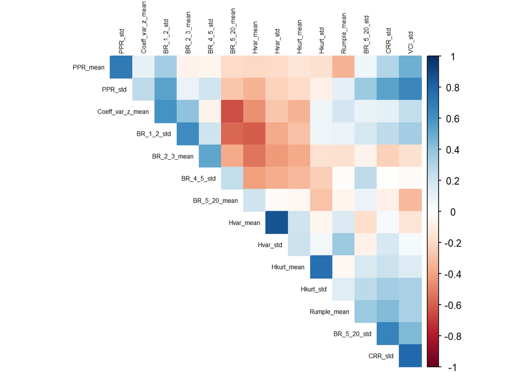

```r
cor_matrix_final <- cor(pca_input, use = "pairwise.complete.obs")

corrplot(cor_matrix_final,
         method = "color",
         type = "upper",
         tl.cex = 0.5,
         tl.col = "black",
         order = "hclust",
         diag = FALSE)
```

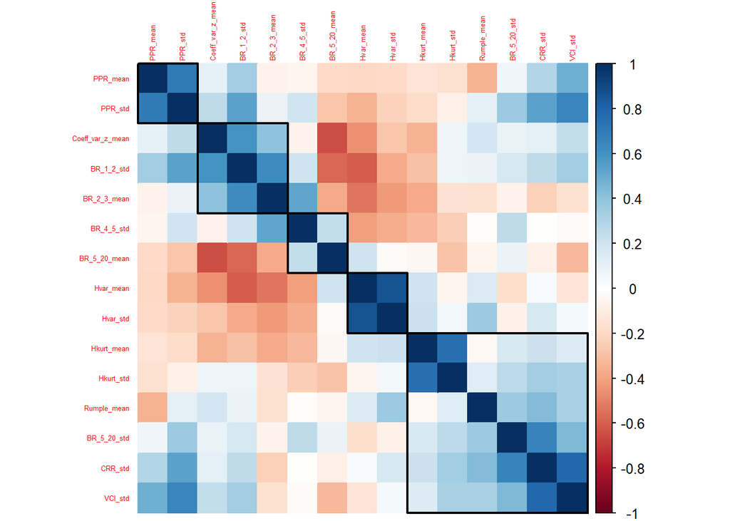

```r
corrplot(cor_matrix_final,
         order   = "hclust",
         addrect = 5,
         method  = "color",
         tl.cex  = 0.4)
```

## PCA

```r
fit <- prcomp(pca_input, center = TRUE, scale. = TRUE)
summary(fit)
```

```
## Importance of components:
##                          PC1   PC2    PC3    PC4    PC5     PC6     PC7     PC8
## Standard deviation     2.053 1.813 1.3689 1.2824 1.2416 0.86352 0.65824 0.56438
## Proportion of Variance 0.281 0.219 0.1249 0.1096 0.1028 0.04971 0.02889 0.02123
## Cumulative Proportion  0.281 0.500 0.6250 0.7346 0.8374 0.88709 0.91598 0.93722
##                            PC9    PC10    PC11    PC12    PC13    PC14    PC15
## Standard deviation     0.52998 0.41585 0.37573 0.33892 0.31369 0.27251 0.24343
## Proportion of Variance 0.01873 0.01153 0.00941 0.00766 0.00656 0.00495 0.00395
## Cumulative Proportion  0.95594 0.96747 0.97688 0.98454 0.99110 0.99605 1.00000
```

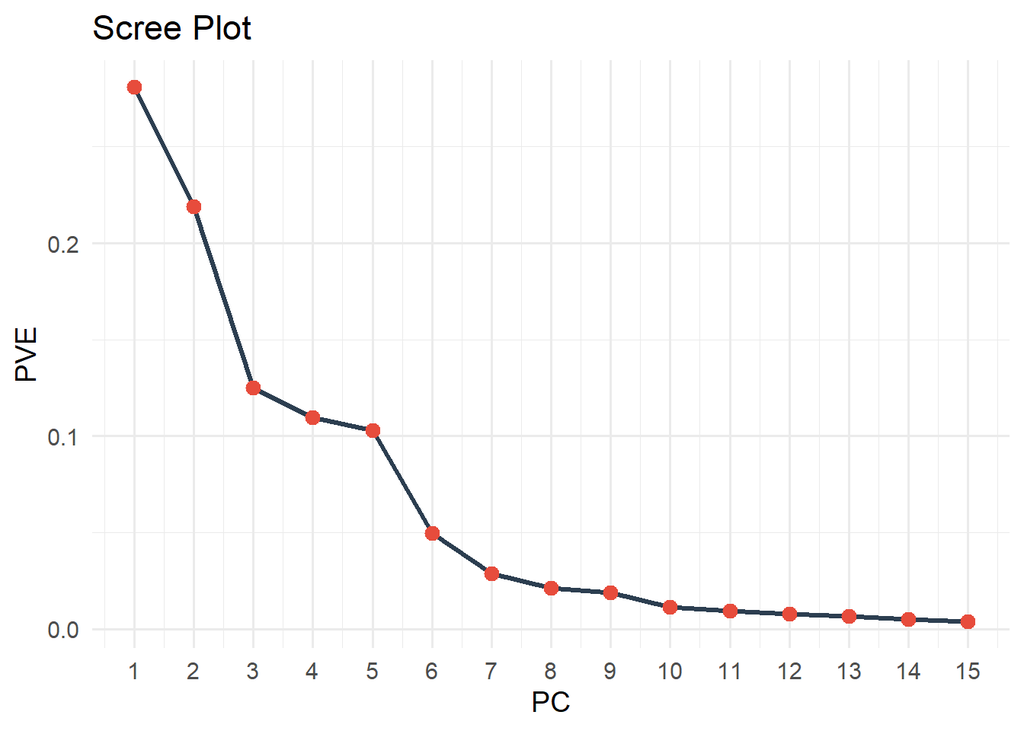

```r
pve <- fit$sdev^2 / sum(fit$sdev^2)

scree <- data.frame(PC = 1:15, PVE = pve[1:15])

ggplot(scree, aes(x = PC, y = PVE)) +
  geom_line(linewidth = 1.2, color = "#2C3E50") +
  geom_point(size = 3, color = "#E74C3C") +
  scale_x_continuous(breaks = 1:15) +
  labs(title = "Scree Plot", x = "PC", y = "PVE") +
  theme_minimal(base_size = 14)
```

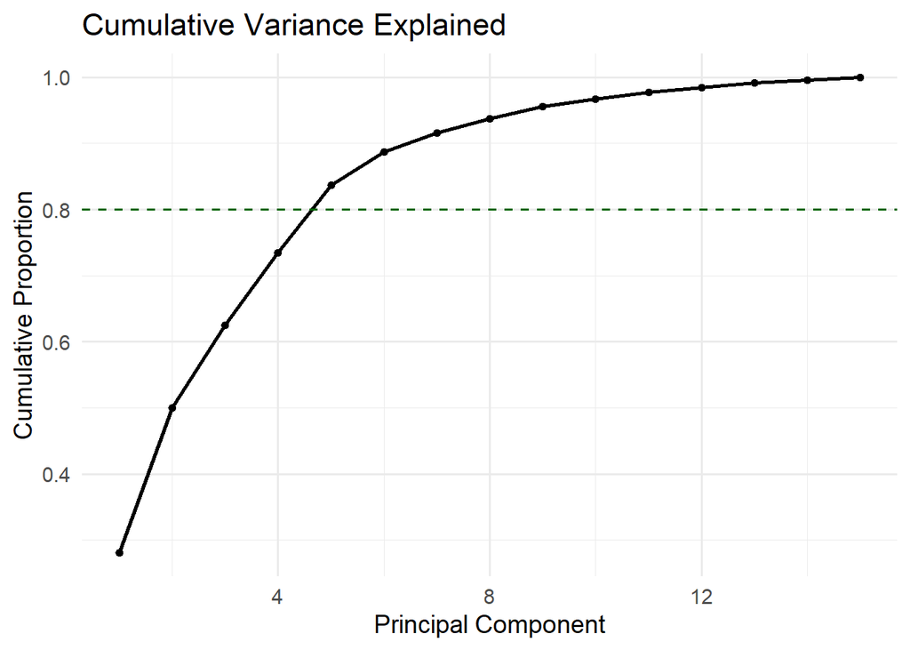

```r
cumulative <- data.frame(
  PC         = 1:length(pve),
  Cumulative = cumsum(pve)
)

ggplot(cumulative, aes(x = PC, y = Cumulative)) +
  geom_line(linewidth = 1) +
  geom_point(size = 1.5) +
  geom_hline(yintercept = 0.8, linetype = "dashed", color = "darkgreen") +
  labs(title = "Cumulative Variance Explained",
       x     = "Principal Component",
       y     = "Cumulative Proportion") +
  theme_minimal(base_size = 14)
```

```
## Ignoring unknown labels:
## • linetype : "Typ lesa"
```

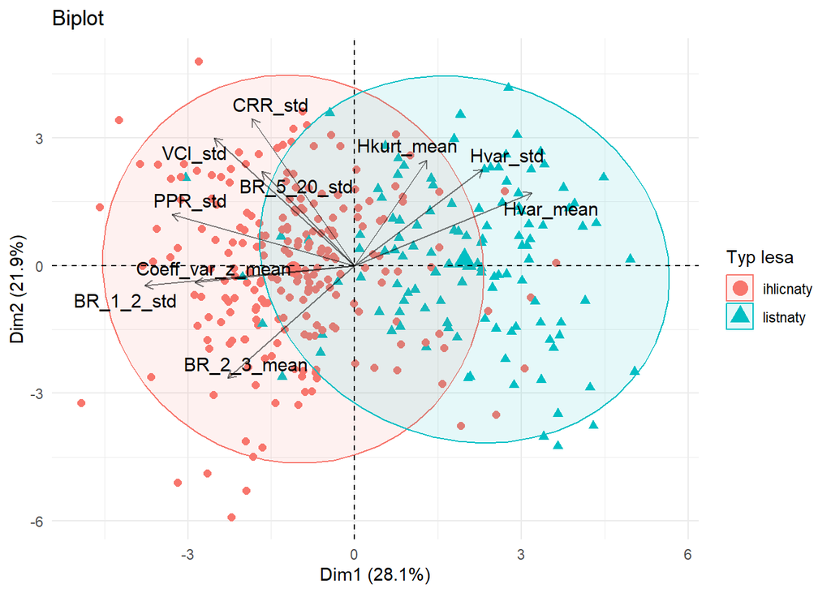

```r
pca_scores          <- as.data.frame(fit$x)
pca_scores$ForestName <- forest_names
pca_scores$Type     <- forest_types
pca_scores$SegmentID  <- combined_binary$Segment
pca_scores$size <- combined_binary$Hectares
pca_scores$hodnotseg <- as.factor(combined_binary$HodnotSeg)

fviz_pca_biplot(fit,
                geom.ind     = "point",
                habillage    = pca_scores$Type,
                pointsize    = 2,
                addEllipses  = TRUE,
                ellipse.level = 0.95,
                col.var      = "black",
                alpha.var    = 0.5,
                select.var   = list(contrib = 10),
                repel        = TRUE,
                legend.title = "Typ lesa") +
  theme_minimal() +
  ggtitle("Biplot")
```

## Interaktívny PCA scatter plot

```r
plot_ly(
  data   = pca_scores,
  x      = ~PC1,
  y      = ~PC2,
  size   = ~size,
  sizes  = c(5, 30),
  type   = "scatter",
  mode   = "markers",
  symbol = ~hodnotseg,
  marker = list(
    sizemode = "diameter",
    opacity = 0.7,
    line = list(width = 0.5, color = "white")
  ),
  color  = ~as.factor(Type),
  colors = c("red", "blue", "darkgreen", "pink", "cyan"),
  text   = ~paste0("Forest: ", ForestName, "<br>ID: ", SegmentID, "<br>ha: ",size),
  hoverinfo = "text"
)
```

[interactive chart not shown]

```r
plot_ly(
  data = pca_scores,
  x = ~PC1,
  y = ~PC6,
  z = ~PC5,
  size   = ~size,
  sizes  = c(5, 30),
  type   = "scatter3d",
  mode   = "markers",
  marker = list(
    sizemode = "diameter",
    opacity = 0.8,
    line = list(width = 0.5, color = "white")
  ),
  color = ~as.factor(Type),
  colors = "Set1",
  text = ~paste0("Forest: ", ForestName, "<br>ID: ", SegmentID),
  hoverinfo = "text"
)
```

[interactive chart not shown]

```r
plot_ly(
  data = pca_scores,
  x = ~PC1,
  y = ~PC2,
  z = ~PC4,
  size   = ~size,
  sizes  = c(5, 30),
  type   = "scatter3d",
  mode   = "markers",
  marker = list(
    sizemode = "diameter",
    opacity = 0.8,
    line = list(width = 0.5, color = "white")
  ),
  color=~as.factor(Type),
  colors = "Set1",
  text = ~paste0("Forest: ", ForestName, "<br>ID: ", SegmentID),
  hoverinfo = "text"
)
```

[interactive chart not shown]

```r
dominant_biotopes <- combined_binary |>
  group_by(Segment) |>
  slice_max(order_by = Percento, n = 1, with_ties = FALSE) |>
  select(Segment, DominantBiotop = BiotopID) |>
  ungroup()


pca_scores2 <- as.data.frame(fit$x) |>
  mutate(
    SegmentID = combined_binary$Segment,
    size = combined_binary$Hectares
  ) |>
  left_join(dominant_biotopes, by = c("SegmentID" = "Segment"))


pca_scores2 <- pca_scores2 |>mutate(
    BiotopGroup = case_when(
      DominantBiotop %in% c("Ls3.1","Ls3.51","Ls3.52") ~ "Ls3",
      DominantBiotop %in% c("Ls5.2","Ls5.3","Ls5.4")   ~ "Ls5",
      DominantBiotop %in% c("Ls7.2","Ls7.4")           ~ "Ls7",
      DominantBiotop %in% c("Ls9.1","Ls9.2","Ls9.3","Ls9.4") ~ "Ls9",
      TRUE ~ DominantBiotop
    ),

    BiotopName = case_when(
    BiotopGroup == "Ls3"   ~ "Ls3 – Dubové lesy",
    BiotopGroup == "Ls5"   ~ "Ls5 – Bukové a listnaté bukové lesy",
    BiotopGroup == "Ls7"   ~ "Ls7 – Rašeliniskové lesy",
    BiotopGroup == "Ls9"   ~ "Ls9 – Smrekové lesy",
    BiotopGroup == "Ls8"   ~ "Ls8 – Jedľové a jedľovo-smrekové lesy",
    BiotopGroup == "Kr10"  ~ "Kr10 – Kosodrevina",
    BiotopGroup == "Ls1.3" ~ "Ls1.3 – Jaseňovo-jelšové podhorské lužné lesy",
    BiotopGroup == "Ls2.1" ~ "Ls2.1 – Dubovo-hrabové lesy karpatské",
    BiotopGroup == "Ls4"   ~ "Ls4 – Lipovo-javorové sutinové lesy",
    BiotopGroup == "Ls6.2" ~ "Ls6.2 – Reliktné vápnomilné borovicové a smrekovcové lesy",
    TRUE ~ BiotopGroup
  )
  )

plot_ly(
  data = pca_scores2,
  x = ~PC1,
  y = ~PC2,
  size = ~size,
  sizes = c(5, 30),
  type = "scatter",
  mode = "markers",
  marker = list(
    sizemode = "diameter",
    opacity = 1,
    line = list(width = 0.5, color = "white")
  ),
  color = ~as.factor(BiotopName),
  colors = "Set3",
  text = ~paste0("ID: ", SegmentID, "<br>Biotop: ", DominantBiotop)
)
```

[interactive chart not shown]

```r
plot_ly(
  data = pca_scores2,
  x = ~PC1,
  y = ~PC6,
  z = ~PC5,
  size   = ~size,
  sizes  = c(5, 30),
  type   = "scatter3d",
  mode   = "markers",
  marker = list(
    sizemode = "diameter",
    opacity = 0.8,
    line = list(width = 0.5, color = "white")
  ),
  color = ~as.factor(BiotopName),
  colors = "Set3",
  text = ~paste0("ID: ", SegmentID, "<br>Biotop: ", DominantBiotop)
)
```

[interactive chart not shown]

```r
biotop_colors <- c(
  "Kr10 – Kosodrevina"                                         = "#3dac8b",
  "Ls1.3 – Jaseňovo-jelšové podhorské lužné lesy"             = "#df7728",
  "Ls2.1 – Dubovo-hrabové lesy karpatské"                     = "#8a85be",
  "Ls3 – Dubové lesy"                                         = "#eb499b",
  "Ls4 – Lipovo-javorové sutinové lesy"                       = "#7db340",
  "Ls5 – Bukové a listnaté bukové lesy"                       = "#eab828",
  "Ls6.2 – Reliktné vápnomilné borovicové a smrekovcové lesy" = "#ff0000",
  "Ls7 – Rašeliniskové lesy"                                  = "#f6b295",
  "Ls8 – Jedľové a jedľovo-smrekové lesy"                     = "#a2cee3",
  "Ls9 – Smrekové lesy"                                       = "#792f85"
)

p_biotopy <- ggplot(pca_scores2, aes(x = PC1, y = PC2, color = BiotopName, size = size)) +
  geom_point(alpha = 0.9) +
  scale_color_manual(
    values = biotop_colors,
    labels = stringr::str_wrap(names(biotop_colors), width = 25)
  ) +
  scale_size_continuous(
    range  = c(1, 8),
    name   = "Plocha (ha)",
    breaks = c(0.5, 1, 2, 5, 10, 20)
  ) +
  geom_hline(yintercept = 0, linetype = "dashed", color = "grey50", linewidth = 0.5) +
  geom_vline(xintercept = 0, linetype = "dashed", color = "grey50", linewidth = 0.5) +
  labs(x = "PC1 (28,1 %)", y = "PC2 (21,9 %)", color = " ") +
  guides(
    color = guide_legend(override.aes = list(size = 4), byrow = TRUE),
    size  = guide_legend()
  ) +
  theme_bw(base_size = 18) +
  theme(
    legend.position  = "right",
    legend.text      = element_text(size = 16),
    legend.title     = element_text(size = 18, face = "bold"),
    legend.key.size  = unit(1, "lines"),
    legend.spacing.y = unit(0.3, "cm")
  )

ggsave("biotopy_scatter.png", plot = p_biotopy, width = 11, height = 6, dpi = 300)
```

## Loadingy

```r
get_top_contributors <- function(pca_fit, pc_num, n = 10) {
  loadings <- pca_fit$rotation[, pc_num]
  top_vars <- sort(abs(loadings), decreasing = TRUE)[1:n]
  data.frame(
    Variable = names(top_vars),
    Loading = loadings[names(top_vars)],
    PC = paste0("PC", pc_num)
  )
}

top_pc1 <- get_top_contributors(fit, 1)
top_pc2 <- get_top_contributors(fit, 2)



rbind(top_pc1, top_pc2)
```

```
##                          Variable    Loading  PC
## BR_1_2_std             BR_1_2_std -0.4202063 PC1
## PPR_std                   PPR_std -0.3659474 PC1
## Hvar_mean               Hvar_mean  0.3550061 PC1
## Coeff_var_z_mean Coeff_var_z_mean -0.3193663 PC1
## VCI_std                   VCI_std -0.2813380 PC1
## Hvar_std                 Hvar_std  0.2565584 PC1
## BR_2_3_mean           BR_2_3_mean -0.2542981 PC1
## BR_5_20_mean         BR_5_20_mean  0.2541673 PC1
## PPR_mean                 PPR_mean -0.2474949 PC1
## CRR_std                   CRR_std -0.2058509 PC1
## CRR_std1                  CRR_std  0.4348669 PC2
## VCI_std1                  VCI_std  0.3778423 PC2
## BR_2_3_mean1          BR_2_3_mean -0.3343980 PC2
## Hkurt_mean             Hkurt_mean  0.3124081 PC2
## Hkurt_std               Hkurt_std  0.3105741 PC2
## Hvar_std1                Hvar_std  0.2839987 PC2
## BR_5_20_std           BR_5_20_std  0.2792163 PC2
## Rumple_mean           Rumple_mean  0.2727765 PC2
## Hvar_mean1              Hvar_mean  0.2149400 PC2
## BR_4_5_std             BR_4_5_std -0.2141506 PC2
```

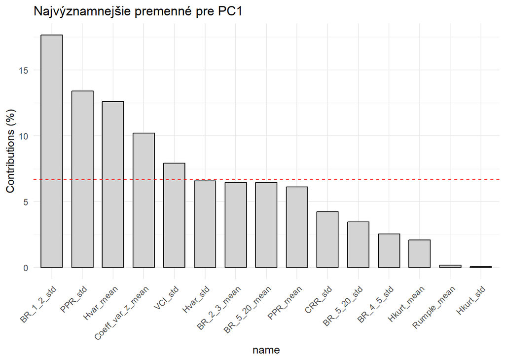

```r
fviz_contrib(fit, choice = "var", axes = 1, top = 20, fill = "lightgray", color = "black") +
  theme_minimal() +
  ggtitle("Najvýznamnejšie premenné pre PC1") +
  theme(axis.text.x = element_text(angle = 45, vjust = 1, hjust = 1))
```

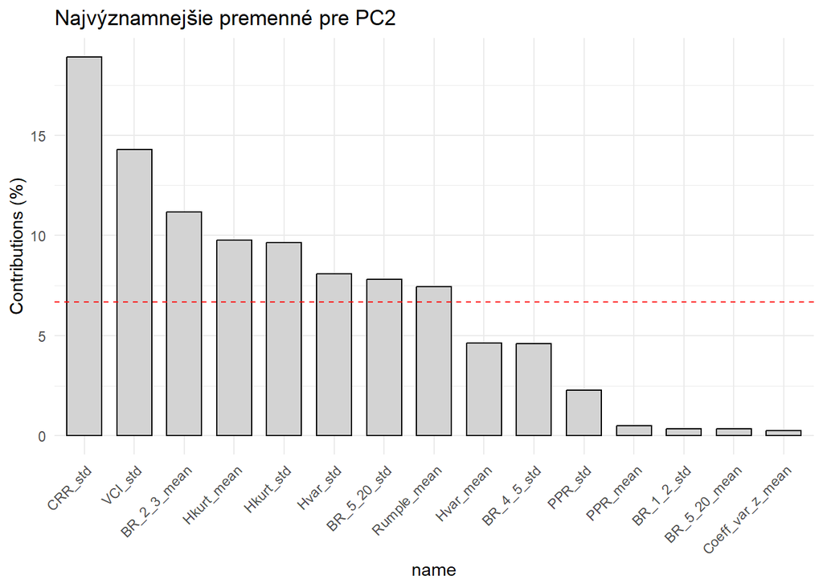

```r
fviz_contrib(fit, choice = "var", axes = 2, top = 20, fill = "lightgray", color = "black") +
  theme_minimal() +
  ggtitle("Najvýznamnejšie premenné pre PC2") +
  theme(axis.text.x = element_text(angle = 45, vjust = 1, hjust = 1))
```

## Interaktívne boxploty metrík

```r
long_data_final <- combined_binary |>
  select(Typ, all_of(names(pca_input))) |>
  pivot_longer(-Typ, names_to = "Variable", values_to = "Value")

shared_df <- SharedData$new(long_data_final)

filter_menu <- filter_select(
  id = "var_selector",
  label = "metrika:",
  sharedData = shared_df,
  group = ~Variable,
  multiple = FALSE
)

p_dynamic <- plot_ly(shared_df,
        x = ~Typ,
        y = ~Value,
        color = ~Typ,
        colors = c("ihlicnaty" = "#1B5E20", "listnaty" = "#E65100"),
        type = "box",
        boxpoints = "all",
        jitter = 0.5,
        pointpos = 0,
        marker = list(
          opacity = 0.4,
          size = 4,
          line = list(width = 0)
        ),
        line = list(width = 2)
) |>
  layout(
    yaxis = list(title = "Value"),
    xaxis = list(title = ""),
    showlegend = FALSE,
    margin = list(t = 50)
  )

bscols(
  widths = c(3, 9),
  list(filter_menu),
  p_dynamic
)
```

metrika:

[interactive chart not shown]

## LDA

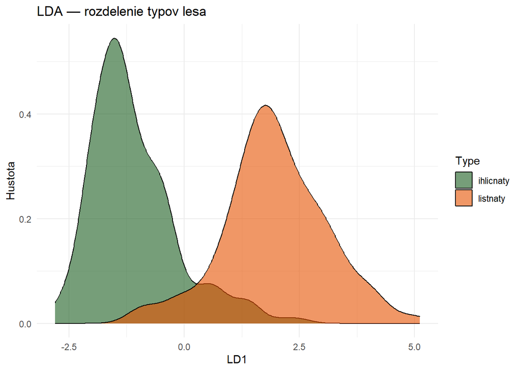

```r
#lda_fit <- lda(x = scale(pca_input), grouping = forest_types)
lda_fit <- lda(x = pca_scores[, 1:7], grouping = forest_types)

lda_scores <- as.data.frame(predict(lda_fit)$x)
lda_scores$Type <- forest_types
lda_scores$ForestName <- forest_names
lda_scores$SegmentID  <- combined_binary$Segment
lda_scores$Poznamka <-combined_binary$Poznamka
lda_scores$Percento_dom <-combined_binary$Percento
lda_scores$Percento_type<-combined_binary$total_percent
lda_scores$size <- combined_binary$Hectares


ggplot(lda_scores, aes(x = LD1, fill = Type)) +
  geom_density(alpha = 0.6) +
  scale_fill_manual(values = c("ihlicnaty" = "#1B5E20", "listnaty" = "#E65100")) +
  theme_minimal() +
  labs(title = "LDA — rozdelenie typov lesa", x = "LD1", y = "Hustota")
```

```r
predictions <- predict(lda_fit)$class
lda_scores$PredictedType <- predictions
wrong_samples <- lda_scores[lda_scores$Type != lda_scores$PredictedType, ]
print(wrong_samples[, c("ForestName", "Type", "PredictedType", "LD1","SegmentID","Poznamka","Percento_dom","Percento_type")])
```

```
##                ForestName      Type PredictedType         LD1 SegmentID
## 36               Zrubiska ihlicnaty      listnaty  1.38358671    405/S4
## 45        Klenovsky_Vepor ihlicnaty      listnaty  0.64438062     44/S3
## 49        Klenovsky_Vepor ihlicnaty      listnaty  0.72841908     44/S4
## 56             Kornietova ihlicnaty      listnaty  2.51920570     46/S4
## 57              Kundracka ihlicnaty      listnaty  0.87891094     47/S3
## 58              Kundracka ihlicnaty      listnaty  0.78773940     47/S3
## 110              Spiglova  listnaty     ihlicnaty  0.31758798    512/S3
## 127               Obrstin ihlicnaty      listnaty  1.09387896    534/S4
## 128               Obrstin ihlicnaty      listnaty  1.41634369    534/S4
## 129               Obrstin ihlicnaty      listnaty  1.54744786    534/S4
## 146 Raztocka_hola_-_sever  listnaty     ihlicnaty -0.08268364    545/S2
## 147 Raztocka_hola_-_sever  listnaty     ihlicnaty  0.52333078    545/S2
## 149 Raztocka_hola_-_sever  listnaty     ihlicnaty  0.16647339    545/S2
## 150                Straze  listnaty     ihlicnaty -0.33776830    550/S1
```

[output cut: 37 more lines]

```r
vars <- paste0("PC", 1:7)

X <- as.matrix(pca_scores[, vars])
# X= riadky sú segmenty, stlpce su ich hodnoty PC1 az 7
g <- droplevels(as.factor(forest_types)) #to len ulozi zaradom ci je listnaty/ihlicnaty seg
lev <- levels(g)#ia ake su triedy, my mame 2

# priemery tried
mu1 <- colMeans(X[g == lev[1], , drop = FALSE])
mu2 <- colMeans(X[g == lev[2], , drop = FALSE])

# spoločná kovariančná matica tried
S_pooled <- matrix(0, nrow = length(vars), ncol = length(vars),
                   dimnames = list(vars, vars))

for (cl in lev) {
  Xg <- X[g == cl, , drop = FALSE]
  S_pooled <- S_pooled + (nrow(Xg) - 1) * cov(Xg)
}

S_pooled <- S_pooled / (nrow(X) - length(lev))

# inverzia kovariančnej matice
Sinv <- solve(S_pooled)

# priory z LDA modelu
pi1 <- lda_fit$prior[lev[1]]
pi2 <- lda_fit$prior[lev[2]]

# parametre diskriminačných funkcií delta_1 a delta_2
a1 <- as.vector(Sinv %*% mu1)
a2 <- as.vector(Sinv %*% mu2)

names(a1) <- vars
names(a2) <- vars

b1 <- as.numeric(-0.5 * t(mu1) %*% Sinv %*% mu1 + log(pi1))
b2 <- as.numeric(-0.5 * t(mu2) %*% Sinv %*% mu2 + log(pi2))

# hranica: delta_1 = delta_2
# teda: (a1 - a2)^T x + (b1 - b2) = 0

A <- a1 - a2
B <- b1 - b2

xvar <- "PC1"
yvar <- "PC6"
zvar <- "PC5"

other <- setdiff(vars, c(xvar, yvar, zvar))

fixed_other <- colMeans(X[, other, drop = FALSE])

axis_x <- seq(min(X[, xvar]), max(X[, xvar]), length.out = 40)
axis_y <- seq(min(X[, yvar]), max(X[, yvar]), length.out = 40)

const_other <- sum(A[other] * fixed_other)

surface_z <- outer(axis_x, axis_y, function(x, y) {
  -(A[xvar] * x + A[yvar] * y + const_other + B) / A[zvar]
})

p_3d <-plot_ly() %>%
  add_markers(
    data = pca_scores,
    x = ~PC1,
    y = ~PC6,
    z = ~PC5,
    color = ~as.factor(forest_types),
    colors = c("#f8766d", "#00bfc4"),
    marker = list(
    size = 4,
    sizemode = "diameter",
    opacity = 1),
    text = ~paste0("Forest: ", ForestName, "<br>ID: ", SegmentID),
    hoverinfo = "text"
  ) %>%
  add_surface(
    x = ~axis_x,
    y = ~axis_y,
    z = ~t(surface_z),
    opacity = 0.75,
    showscale = FALSE,
    colorscale = list(c(0, 1), c("#708090", "#708090"))
  ) %>%
  layout(
    scene = list(
      xaxis = list(title = xvar),
      yaxis = list(title = yvar),
      zaxis = list(title = zvar, range = c(-6, 5))
    )
  )


p_3d
```

[interactive chart not shown]

```
## Ignoring unknown labels:
## • linetype : "Typ lesa"
```

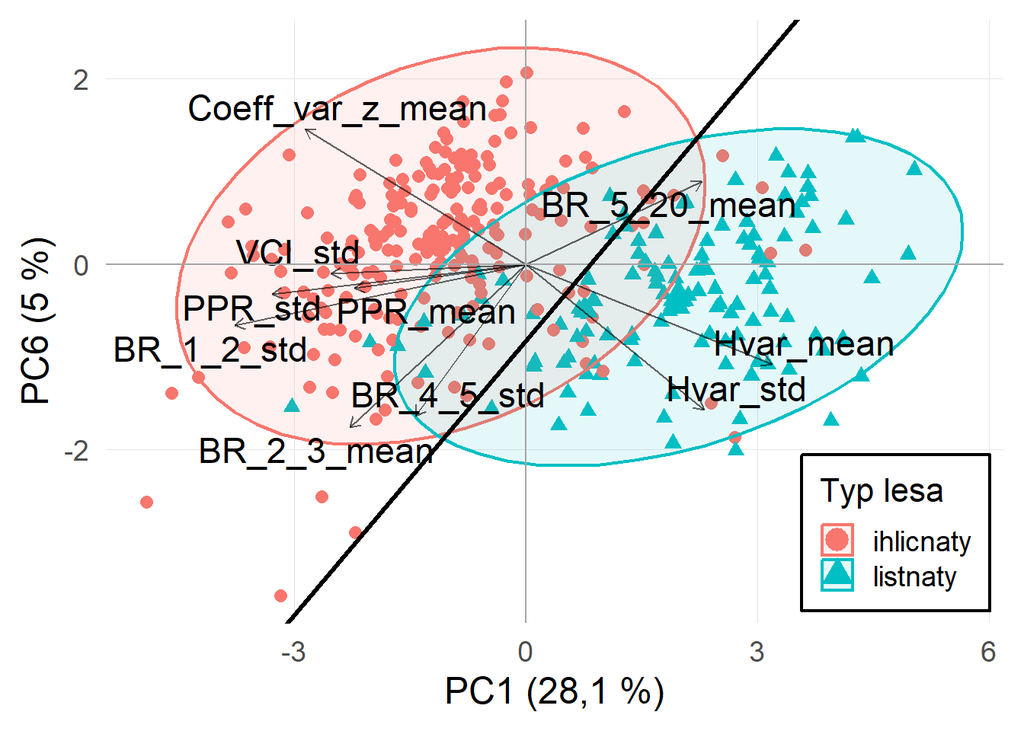

```r
xvar_2d <- "PC1"
yvar_2d <- "PC6"

# všetky komponenty, ktoré v 2D grafe nezobrazujeme
# sem teraz patrí aj PC5
other_2d <- setdiff(vars, c(xvar_2d, yvar_2d))

# fixujeme ich na priemerné hodnoty
fixed_other_2d <- colMeans(X[, other_2d, drop = FALSE])

# ich príspevok do rovnice hranice
const_other_2d <- sum(A[other_2d] * fixed_other_2d)

# rovnica hranice:
# A_PC1 * PC1 + A_PC6 * PC6 + const_other_2d + B = 0
# vyjadríme PC6 ako y:
# PC6 = -(A_PC1 * PC1 + const_other_2d + B) / A_PC6

slope_2d <- -A[xvar_2d] / A[yvar_2d]
intercept_2d <- -(const_other_2d + B) / A[yvar_2d]

p_biplot <- fviz_pca_biplot(fit,
                axes          = c(1, 6),
                geom.ind      = "point",
                habillage     = pca_scores$Type,
                pointsize     = 2.5,
                addEllipses   = TRUE,
                ellipse.level = 0.95,
                col.var       = "black",
                alpha.var     = 0.6,
                select.var    = list(contrib = 10),
                labelsize     = 6,
                repel         = TRUE,
                legend.title  = "Typ lesa",
                axes.linetype = "blank") +
  theme_minimal(base_size = 18) +
  labs(
    x = "PC1 (28,1 %)",
    y = "PC6 (5 %)",
    title = NULL
  ) +
  theme(
    axis.title      = element_text(size = 18),
    axis.text       = element_text(size = 14),
    legend.title    = element_text(size = 16),
    legend.text     = element_text(size = 14),
    legend.position = c(0.88, 0.15),
    legend.background = element_rect(fill = "white", color = "black"),
    panel.grid.major = element_line(color = "grey90", linewidth = 0.3),
    panel.grid.minor = element_blank(),
    plot.margin      = margin(10, 10, 10, 10)
  )


p_biplot_with_line <- p_biplot +
  geom_hline(yintercept = 0, color = "grey65", linewidth = 0.5) +
  geom_vline(xintercept = 0, color = "grey65", linewidth = 0.5) +
  geom_abline(
    intercept = intercept_2d,
    slope = slope_2d,
    color = "black",
    linewidth = 1.2
  )

# 3. Zobrazenie a uloženie
print(p_biplot_with_line)
```

```r
ggsave("biplot_PC1_PC6_LDA.png", plot = p_biplot_with_line, width = 11, height = 7, dpi = 300)
```

```
## Ignoring unknown labels:
## • linetype : "Typ lesa"
```

ABsolutne hodnoty !!

```r
lda_loadings <- sort(abs(lda_fit$scaling[, 1]), decreasing = TRUE)
print(head(lda_loadings, 15))
```

```
##        PC6        PC1        PC5        PC3        PC2        PC4        PC7
## 0.76601560 0.75497388 0.37576878 0.22910566 0.07059199 0.03400994 0.01000422
```

```r
plot_ly(
  data = lda_scores,
  x = ~LD1,
  y = ~jitter(rep(0, nrow(lda_scores)), amount = 0.3),
  size   = ~size,
  sizes  = c(5, 30),
  type   = "scatter",
  mode   = "markers",
  marker = list(
    sizemode = "diameter",
    opacity = 0.7,
    line = list(width = 0.5, color = "white")
  ),
  color = ~as.factor(Type),
  colors = c("ihlicnaty" = "#1B5E20", "listnaty" = "#E65100"),
  text = ~paste0("Forest: ", ForestName, "<br>Type: ", Type, "<br>Segment: ",SegmentID),
  hoverinfo = "text"
) |>
  layout(
    title = "LDA scatter",
    xaxis = list(title = "LD1"),
    yaxis = list(title = "", showticklabels = FALSE, zeroline = FALSE),
    showlegend = TRUE
  )
```

[interactive chart not shown]

```r
set.seed(123)

df <- data.frame(
  forest_types = as.factor(forest_types),
  pca_input
)

# LOOCV
lda_loocv <- train(
  forest_types ~ .,
  data = df,
  method = "lda",
  preProcess = c("center", "scale", "pca"),
  trControl = trainControl(method = "LOOCV", savePredictions = TRUE),preProcOptions = list(thresh = 0.90)
)

cat("\n=== LOOCV ===\n")
```

```
##
## === LOOCV ===
```

```r
print(lda_loocv)
```

```
## Linear Discriminant Analysis
##
## 340 samples
##  15 predictor
##   2 classes: 'ihlicnaty', 'listnaty'
##
## Pre-processing: centered (15), scaled (15), principal component
##  signal extraction (15)
## Resampling: Leave-One-Out Cross-Validation
## Summary of sample sizes: 339, 339, 339, 339, 339, 339, ...
## Resampling results:
##
##   Accuracy   Kappa
##   0.9294118  0.8471452
```

```r
confusionMatrix(lda_loocv$pred$pred, lda_loocv$pred$obs)
```

```
## Confusion Matrix and Statistics
##
##            Reference
## Prediction  ihlicnaty listnaty
##   ihlicnaty       205       11
##   listnaty         13      111
##
##                Accuracy : 0.9294
##                  95% CI : (0.8968, 0.9543)
##     No Information Rate : 0.6412
##     P-Value [Acc > NIR] : <2e-16
##
##                   Kappa : 0.8471
##
##  Mcnemar's Test P-Value : 0.8383
##
##             Sensitivity : 0.9404
##             Specificity : 0.9098
##          Pos Pred Value : 0.9491
##          Neg Pred Value : 0.8952
##              Prevalence : 0.6412
##          Detection Rate : 0.6029
##    Detection Prevalence : 0.6353
##       Balanced Accuracy : 0.9251
##
##        'Positive' Class : ihlicnaty
##
```

```r
# k-fold CV
lda_kfold <- train(
  forest_types ~ .,
  data = df,
  method = "lda",
  preProcess = c("center", "scale", "pca"),
  trControl = trainControl(method = "cv", savePredictions = TRUE, number = 5),
  preProcOptions = list(thresh = 0.90)
)

cat("\n=== 5-FOLD CV ===\n")
```

```
##
## === 5-FOLD CV ===
```

```r
print(lda_kfold)
```

```
## Linear Discriminant Analysis
##
## 340 samples
##  15 predictor
##   2 classes: 'ihlicnaty', 'listnaty'
##
## Pre-processing: centered (15), scaled (15), principal component
##  signal extraction (15)
## Resampling: Cross-Validated (5 fold)
## Summary of sample sizes: 271, 273, 271, 273, 272
## Resampling results:
##
##   Accuracy   Kappa
##   0.9323415  0.8531132
```

```r
confusionMatrix(lda_kfold$pred$pred, lda_kfold$pred$obs)
```

```
## Confusion Matrix and Statistics
##
##            Reference
## Prediction  ihlicnaty listnaty
##   ihlicnaty       206       11
##   listnaty         12      111
##
##                Accuracy : 0.9324
##                  95% CI : (0.9002, 0.9566)
##     No Information Rate : 0.6412
##     P-Value [Acc > NIR] : <2e-16
##
##                   Kappa : 0.8533
##
##  Mcnemar's Test P-Value : 1
##
##             Sensitivity : 0.9450
##             Specificity : 0.9098
##          Pos Pred Value : 0.9493
##          Neg Pred Value : 0.9024
##              Prevalence : 0.6412
##          Detection Rate : 0.6059
##    Detection Prevalence : 0.6382
##       Balanced Accuracy : 0.9274
##
##        'Positive' Class : ihlicnaty
##
```

## Testy na LDA

Test homogenity kovariančných matíc

```r
box_test <- boxM(pca_input, forest_types)
print(box_test)
```

```
##
##  Box's M-test for Homogeneity of Covariance Matrices
##
## data:  pca_input by forest_types
## Chi-Sq (approx.) = 1596.515, df = 120, p-value = < 2.2e-16
```

dosť sa líšia, hm

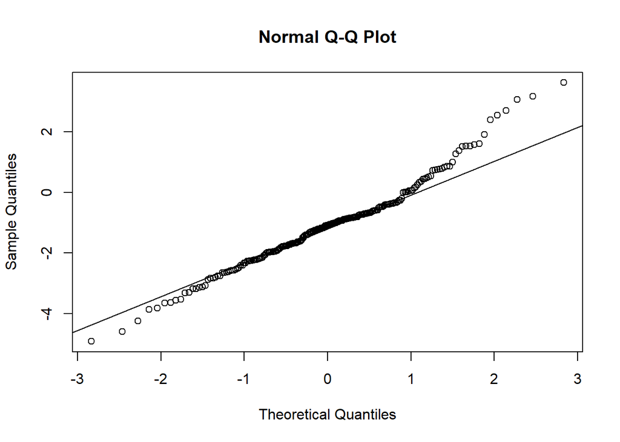

```r
qqnorm(pca_scores$PC1[forest_types == "ihlicnaty"])
qqline(pca_scores$PC1[forest_types == "ihlicnaty"])
```

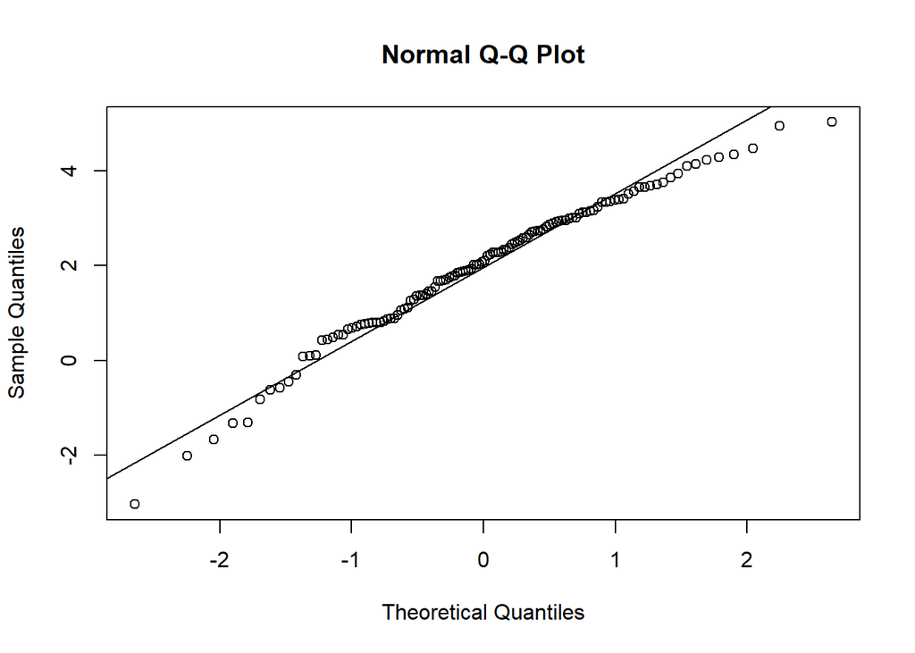

```r
qqnorm(pca_scores$PC1[forest_types == "listnaty"])
qqline(pca_scores$PC1[forest_types == "listnaty"])
```

```r
by(pca_scores$PC1, forest_types, shapiro.test)
```

```
## forest_types: ihlicnaty
##
##  Shapiro-Wilk normality test
##
## data:  dd[x, ]
## W = 0.9769, p-value = 0.001211
##
## ------------------------------------------------------------
## forest_types: listnaty
##
##  Shapiro-Wilk normality test
##
## data:  dd[x, ]
## W = 0.97664, p-value = 0.03233
```

```r
 ctrl <- trainControl(method = "cv", number = 5)

lda_model <- train(
  forest_types ~ .,
  data = df,
  method = "lda",
  preProcess = c("center", "scale", "pca"),
  trControl = ctrl
)


qda_model <- train(
  forest_types ~ .,
  data = df,
  method = "qda",
  preProcess = c("center", "scale", "pca"),
  trControl = ctrl
)

lda_model
```

```
## Linear Discriminant Analysis
##
## 340 samples
##  15 predictor
##   2 classes: 'ihlicnaty', 'listnaty'
##
## Pre-processing: centered (15), scaled (15), principal component
##  signal extraction (15)
## Resampling: Cross-Validated (5 fold)
## Summary of sample sizes: 272, 271, 272, 273, 272
## Resampling results:
##
##   Accuracy   Kappa
##   0.9265508  0.8397246
```

```r
qda_model
```

```
## Quadratic Discriminant Analysis
##
## 340 samples
##  15 predictor
##   2 classes: 'ihlicnaty', 'listnaty'
##
## Pre-processing: centered (15), scaled (15), principal component
##  signal extraction (15)
## Resampling: Cross-Validated (5 fold)
## Summary of sample sizes: 272, 272, 271, 272, 273
## Resampling results:
##
##   Accuracy  Kappa
##   0.932304  0.8558768
```

```r
set.seed(123)
df7 <- data.frame(
  forest_types = as.factor(forest_types),
  pca_scores[, paste0("PC", 1:7)]
)

# LOOCV
lda_loocv <- train(
  forest_types ~ .,
  data = df7,
  method = "lda",
  trControl = trainControl(method = "LOOCV", savePredictions = TRUE)
)
cat("\n=== LOOCV ===\n")
```

```
##
## === LOOCV ===
```

```r
print(lda_loocv)
```

```
## Linear Discriminant Analysis
##
## 340 samples
##   7 predictor
##   2 classes: 'ihlicnaty', 'listnaty'
##
## No pre-processing
## Resampling: Leave-One-Out Cross-Validation
## Summary of sample sizes: 339, 339, 339, 339, 339, 339, ...
## Resampling results:
##
##   Accuracy   Kappa
##   0.9235294  0.8350007
```

```r
confusionMatrix(lda_loocv$pred$pred, lda_loocv$pred$obs)
```

```
## Confusion Matrix and Statistics
##
##            Reference
## Prediction  ihlicnaty listnaty
##   ihlicnaty       203       11
##   listnaty         15      111
##
##                Accuracy : 0.9235
##                  95% CI : (0.89, 0.9494)
##     No Information Rate : 0.6412
##     P-Value [Acc > NIR] : <2e-16
##
##                   Kappa : 0.835
##
##  Mcnemar's Test P-Value : 0.5563
##
##             Sensitivity : 0.9312
##             Specificity : 0.9098
##          Pos Pred Value : 0.9486
##          Neg Pred Value : 0.8810
##              Prevalence : 0.6412
##          Detection Rate : 0.5971
##    Detection Prevalence : 0.6294
##       Balanced Accuracy : 0.9205
##
##        'Positive' Class : ihlicnaty
##
```

```r
set.seed(123)
# k-fold CV
lda_kfold <- train(
  forest_types ~ .,
  data = df7,
  method = "lda",
  trControl = trainControl(method = "cv", savePredictions = TRUE, number = 5)
)
cat("\n=== 5-FOLD CV ===\n")
```

```
##
## === 5-FOLD CV ===
```

```r
print(lda_kfold)
```

```
## Linear Discriminant Analysis
##
## 340 samples
##   7 predictor
##   2 classes: 'ihlicnaty', 'listnaty'
##
## No pre-processing
## Resampling: Cross-Validated (5 fold)
## Summary of sample sizes: 271, 273, 271, 273, 272
## Resampling results:
##
##   Accuracy  Kappa
##   0.914258  0.8184093
```

```r
confusionMatrix(lda_kfold$pred$pred, lda_kfold$pred$obs)
```

```
## Confusion Matrix and Statistics
##
##            Reference
## Prediction  ihlicnaty listnaty
##   ihlicnaty       202       13
##   listnaty         16      109
##
##                Accuracy : 0.9147
##                  95% CI : (0.8798, 0.9421)
##     No Information Rate : 0.6412
##     P-Value [Acc > NIR] : <2e-16
##
##                   Kappa : 0.8156
##
##  Mcnemar's Test P-Value : 0.7103
##
##             Sensitivity : 0.9266
##             Specificity : 0.8934
##          Pos Pred Value : 0.9395
##          Neg Pred Value : 0.8720
##              Prevalence : 0.6412
##          Detection Rate : 0.5941
##    Detection Prevalence : 0.6324
##       Balanced Accuracy : 0.9100
##
##        'Positive' Class : ihlicnaty
##
```

```r
set.seed(123)

qda_loocv <- train(
  forest_types ~ .,
  data = df7,
  method = "qda",
  trControl = trainControl(method = "LOOCV", savePredictions = TRUE)
)

cat("\n=== QDA LOOCV ===\n")
```

```
##
## === QDA LOOCV ===
```

```r
print(qda_loocv)
```

```
## Quadratic Discriminant Analysis
##
## 340 samples
##   7 predictor
##   2 classes: 'ihlicnaty', 'listnaty'
##
## No pre-processing
## Resampling: Leave-One-Out Cross-Validation
## Summary of sample sizes: 339, 339, 339, 339, 339, 339, ...
## Resampling results:
##
##   Accuracy   Kappa
##   0.9264706  0.8438648
```

```r
confusionMatrix(qda_loocv$pred$pred, qda_loocv$pred$obs)
```

```
## Confusion Matrix and Statistics
##
##            Reference
## Prediction  ihlicnaty listnaty
##   ihlicnaty       199        6
##   listnaty         19      116
##
##                Accuracy : 0.9265
##                  95% CI : (0.8934, 0.9519)
##     No Information Rate : 0.6412
##     P-Value [Acc > NIR] : <2e-16
##
##                   Kappa : 0.8439
##
##  Mcnemar's Test P-Value : 0.0164
##
##             Sensitivity : 0.9128
##             Specificity : 0.9508
##          Pos Pred Value : 0.9707
##          Neg Pred Value : 0.8593
##              Prevalence : 0.6412
##          Detection Rate : 0.5853
##    Detection Prevalence : 0.6029
##       Balanced Accuracy : 0.9318
##
##        'Positive' Class : ihlicnaty
##
```

```r
set.seed(123)

qda_kfold <- train(
  forest_types ~ .,
  data = df7,
  method = "qda",
  trControl = trainControl(method = "cv", savePredictions = TRUE, number = 5)
)

cat("\n=== QDA 5-FOLD CV ===\n")
```

```
##
## === QDA 5-FOLD CV ===
```

```r
print(qda_kfold)
```

```
## Quadratic Discriminant Analysis
##
## 340 samples
##   7 predictor
##   2 classes: 'ihlicnaty', 'listnaty'
##
## No pre-processing
## Resampling: Cross-Validated (5 fold)
## Summary of sample sizes: 271, 273, 271, 273, 272
## Resampling results:
##
##   Accuracy   Kappa
##   0.9232997  0.8406883
```

```r
confusionMatrix(qda_kfold$pred$pred, qda_kfold$pred$obs)
```

```
## Confusion Matrix and Statistics
##
##            Reference
## Prediction  ihlicnaty listnaty
##   ihlicnaty       198        6
##   listnaty         20      116
##
##                Accuracy : 0.9235
##                  95% CI : (0.89, 0.9494)
##     No Information Rate : 0.6412
##     P-Value [Acc > NIR] : < 2e-16
##
##                   Kappa : 0.8379
##
##  Mcnemar's Test P-Value : 0.01079
##
##             Sensitivity : 0.9083
##             Specificity : 0.9508
##          Pos Pred Value : 0.9706
##          Neg Pred Value : 0.8529
##              Prevalence : 0.6412
##          Detection Rate : 0.5824
##    Detection Prevalence : 0.6000
##       Balanced Accuracy : 0.9295
##
##        'Positive' Class : ihlicnaty
##
```